# Coding : R Lessons

Date: November 2016

Author : Alice Daish (Data Scientist)

*This R lesson is for students or eager data champions to get an initial glimpse into the world of coding using the open source programming and statistical language R.*

*Download [R](https://www.r-project.org/) and [R studio desktop](https://www.rstudio.com/products/rstudio/download/) to get started.*

### Objectives:

- Learn how to load data into R
- Learn how to make a tree map
- Learn how to make a wordcloud
- Learn how to make a map

### Getting Started

**Set working directory and upload data**

Set the working directory tells R where you want it to find data and files.

For example :

```r
setwd("H:\\GitHub\\RLessons")
```

Now you have told R where you have stored the data. Tell it to read the data you have in your folder including the names of the columns using “header=TRUE”.

**Load Activities Data**

```r
actdata<-read.csv("activitieslist.csv",header=TRUE)
```

This is example data of what activities student’s spend their spare time on.

**View the data** Have a look at the data. Check R has read your data.

```r
View(actdata)
```

```
##                      activities count
## 1  Visiting the British Museum     90
## 2                  Social Media    60
## 3            Netflix/TV/Youtube    50
## 4      Hanging out with friends    50
## 5                      Shopping    10
## 6                           Gym    30
## 7                         Sport    30
## 8     Spending time with family    60
## 9                       Cooking    15
## 10                          Job    70
## 11             Place of worship    10
## 12              Walking the dog    10
## 13                Playing music    40
## 14                  Arts/Crafts    10
## 15                       Gaming    40
## 16                       Cinema    20
```

**Dimension of the data**

```r
dim(actdata)
```

```
## [1] 16  2
```

16 rows and 2 column table

**What is your data made out of?**

```r
str(actdata)
```

```
## 'data.frame':    16 obs. of  2 variables:
##  $ activities: Factor w/ 16 levels "Arts/Crafts",..: 15 12 8 6 11 5 14 13 3 7 ...
##  $ count     : int  90 60 50 50 10 30 30 60 15 70 ...
```

# TreeMap

Lets plot the activties data onto a tree map.

**Install Package**

[Treemap Package](https://www.rdocumentation.org/packages/treemap/versions/2.4-1/topics/treemap)

```r
#install.packages("treemap") #install the package called treemap
library(treemap) #tell R you want to use it now it is install onto your machine
```

**Create your first tree map**

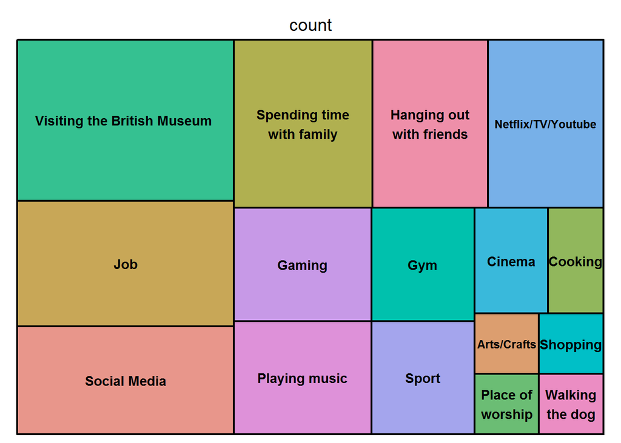

```r
map1<-treemap(actdata, #tell R what data you want to use
        index="activities", #tell R what events you would like it to plot
        vSize="count",  #tell R what quantity you would like it to plot
        type="index")  #what type of treemap do you want to use
```

**Add a title and change the colours**

Colour Brewer

**Red to green colours treemap**

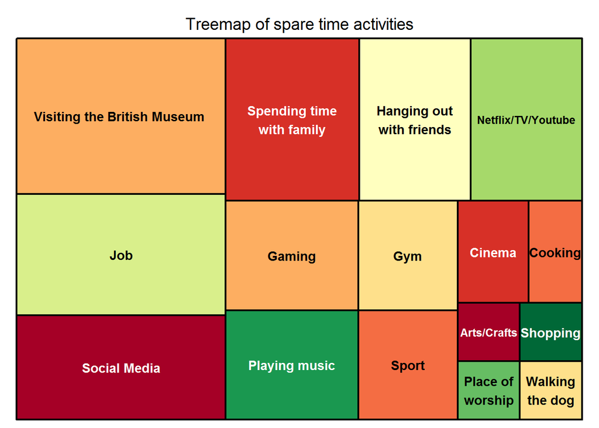

```r
map2<-treemap(actdata,
              index="activities",
              vSize="count",
              palette = "RdYlGn", #Try different colour use the link above
              type="index",
              title="Treemap of spare time activities") #Add title
```

**Bright colours treemap**

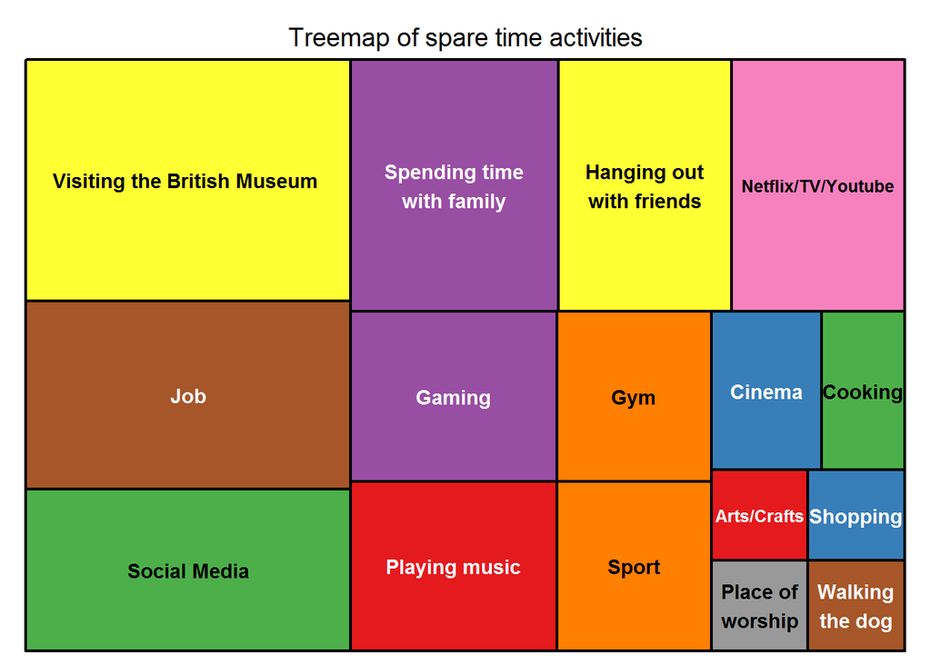

```r
map3<-treemap(actdata,
              index="activities",
              vSize="count",
              palette = "Set1", #Try different colour use the link above
              type="index",
              title="Treemap of spare time activities") #Add title
```

**Red treemap**

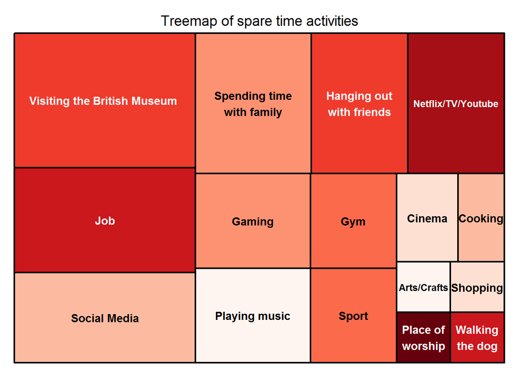

```r
map4<-treemap(actdata,
              index="activities",
              vSize="count",
              palette = "Reds", #Try different colour use the link above
              type="index",
              title="Treemap of spare time activities") #Add title
```

Jump to Top ***

# WordCloud

**Install Packages**

```r
#install.packages("wordcloud") #install the package called wordcloud
library(wordcloud) #tell R you want to use it now it is install onto your machine
```

**Creating a WordCloud**

[Wordcloud Package](https://www.rdocumentation.org/packages/wordcloud/versions/2.5/topics/wordcloud)

**Create a word cloud using the activities data**

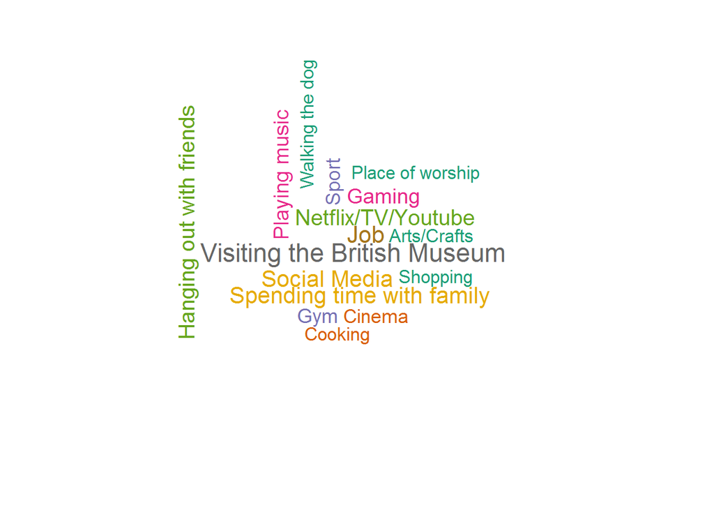

```r
wordcloud1<-wordcloud(actdata$activities,actdata$count, #use the activities name (actdata$activities) and frequency of activites by students (actdata$count)
            scale=c(1.5,1),      #Add a scale so all the words fit on the page
            min.freq=1,          #Minimum word size quantity
            max.words=Inf,       #Max word size quantity
            random.order=FALSE,  #Order of words
            random.color=FALSE,  #Order of colours
            rot.per=.35,         #Rotation of words
            colors=brewer.pal(8, "Dark2")) #Set the colours - Try different Colours brewers
```

Worldclouds work really well with lots of data with a variety of sizes. Lets have a look at the British Museum example.

**Words searched on the British Museum website**

Lets look at the words searched on the British Museum Website and Collections online in August

Load the data for August 2016.

```r
augustdata<-read.csv("augustsearch.csv",header=TRUE)
```

Now you have told R where you have stored the data - tell it so read data you have including the names of the columns.

Create a word cloud using the word searched data.

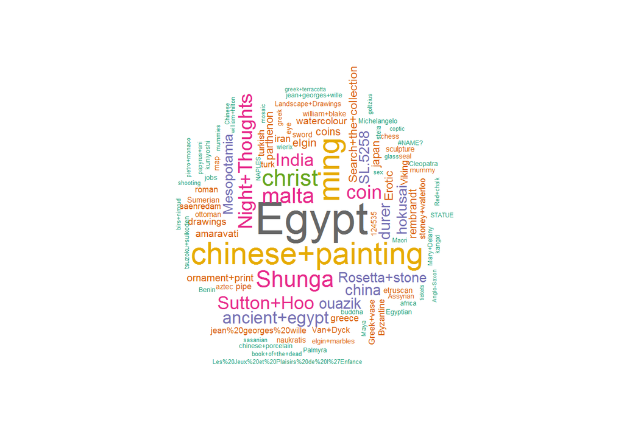

```r
wordcloud2<-wordcloud(augustdata$terms,augustdata$searches, #use the search terms (augustdata$terms) and frequency of searchs (augustdata$searches)
                      scale=c(3,.1),       #Add a scale so all the words fit on the page
                      min.freq=1,          #Minimum word size quantity
                      max.words=Inf,       #Max word size quantity
                      random.order=FALSE,  #Order of words
                      random.color=FALSE,  #Order of colours
                      rot.per=.35,         #Rotation of words
                      colors=brewer.pal(8, "Dark2")) #Set the colours #Try different brewer colours
```

Jump to Top